# TASK 2

```python
import pandas as pd
import matplotlib.pyplot as plt
import numpy as np
from seaborn import heatmap, diverging_palette, histplot, barplot, violinplot, boxplot, pointplot
from sklearn.preprocessing import LabelEncoder
```

```python
class Utils:
    @staticmethod
    def missing_report(data):
        nan_values = pd.DataFrame()
        nan_values['missing_count'] = data.isna().sum()
        nan_values['missing_percentage'] = nan_values['missing_count'] / data.shape[0]

        return nan_values.round(4)

    @staticmethod
    def encode_categories(data):
        le = LabelEncoder()
        numericData = pd.DataFrame(data.select_dtypes(include=['number']))
        labels = dict()
        cat_cols = data.select_dtypes(include=['category', 'object']).columns
        for col in cat_cols:
            le.fit(data[col])
            numericData[col] = le.transform(data[col])
            labels[col] = dict(zip(le.classes_, le.transform(le.classes_)))
        return numericData, labels

    @staticmethod
    def fill_missings(data: pd.DataFrame):
        numeric = data.select_dtypes(include=['number']).columns
        data[numeric] = data[numeric].fillna(data[numeric].mean())

        categorical = data.select_dtypes(include=['category', 'object']).columns
        data[categorical] = data[categorical].fillna(data[categorical].mode().iloc[0])

    @staticmethod
    def corr_heatmap(data):
        corr = data.corr()

        plt.figure(figsize=(20, 20))
        cmap = diverging_palette(220, 220, as_cmap=True)
        heatmap(corr, annot=True, fmt=".3f", cmap = cmap, linewidths=1, square=True, center=0, vmax=1, vmin=-1)
        plt.show()

    @staticmethod
    def describe(data: pd.DataFrame):
        for col in data.columns:
            print('feature:', col)
            print('mode:', data[col].mode().iloc[0])
            if(data[col].dtype != 'object'):
                print('mean:', data[col].mean())
                print('median:', data[col].median())
            print('------------------------------------')

    @staticmethod
    def plot_categorical_numeric_relation(data: pd.DataFrame, numeric_col: str, category_col: str, plots):
        n = len(plots)
        i = 0
        figure, axes = plt.subplots(ncols = n, nrows = 1, figsize=(6 * n,6))
        if('boxplot' in plots):
            boxplot(
                data = data,
                x = category_col,
                y = numeric_col,
                order = data.groupby(category_col)[numeric_col].mean().sort_values().index.to_list(),
                ax = axes[i]
            )
            i += 1

        if('barplot' in plots):
            barplot(
                data = data,
                x = category_col,
                y = numeric_col,
                estimator = 'mean',
                order = data.groupby(category_col)[numeric_col].mean().sort_values().index.to_list(),
                ax = axes[i]
            )
            i += 1

        if('violinplot' in plots):
            violinplot(
                data = data,
                x = category_col,
                y = numeric_col,
                order = data.groupby(category_col)[numeric_col].mean().sort_values().index.to_list(),
                ax = axes[i]
            )
            i += 1
        plt.show()

    @staticmethod
    def salary_mean_based_on_x_through_years(data: pd.DataFrame, feature:str):
        ptable = pd.pivot_table(
            data,
            values = ['Salary_USD'],
            index = ['Work_Year', feature],
            aggfunc = {'Salary_USD': 'mean'}
        )
        display(ptable)

        figure, ax = plt.subplots(figsize = (10, 5))
        pointplot(
            data = data,
            x = 'Work_Year',
            y = 'Salary_USD',
            errorbar = None,
            estimator = 'mean',
            hue = feature,
            ax = ax
        )
        plt.show()
```

## 1. Examine Data

### 1.1 read data

```python
data = pd.read_csv('task2.csv')
```

```python
data.info()
```

```
<class 'pandas.core.frame.DataFrame'>
RangeIndex: 13972 entries, 0 to 13971
Data columns (total 8 columns):
 #   Column            Non-Null Count  Dtype
---  ------            --------------  -----
 0   Work_Year         13972 non-null  int64
 1   Experience_Level  13972 non-null  object
 2   Employment_Type   13972 non-null  object
 3   Job_Title         13972 non-null  object
 4   Salary            13972 non-null  int64
 5   Salary_Currency   13972 non-null  object
 6   Remote_Ratio      13972 non-null  int64
 7   Company_Size      13972 non-null  object
dtypes: int64(3), object(5)
memory usage: 873.4+ KB
```

### 1.2 Handle Duplications

```python
data.duplicated().sum()
```

```
5565
```

```python
data.drop_duplicates(inplace=True)
```

### 1.3 Handle Missing Values

```python
Utils.missing_report(data)
```

|  | missing_count | missing_percentage |
| --- | --- | --- |
| Work_Year | 0 | 0.0 |
| Experience_Level | 0 | 0.0 |
| Employment_Type | 0 | 0.0 |
| Job_Title | 0 | 0.0 |
| Salary | 0 | 0.0 |
| Salary_Currency | 0 | 0.0 |
| Remote_Ratio | 0 | 0.0 |
| Company_Size | 0 | 0.0 |

## 2. Examine Currencies

### 2.1 Histogram

```
{'USD': 7499,
 'GBP': 410,
 'EUR': 339,
 'INR': 52,
 'CAD': 48,
 'AUD': 12,
 'PLN': 7,
 'CHF': 6,
 'SGD': 6,
 'JPY': 4,
 'BRL': 4,
 'DKK': 3,
 'HUF': 3,
 'TRY': 3,
 'NOK': 2,
 'THB': 2,
 'ZAR': 1,
 'HKD': 1,
 'ILS': 1,
 'PHP': 1,
 'NZD': 1,
 'MXN': 1,
 'CLP': 1}
```

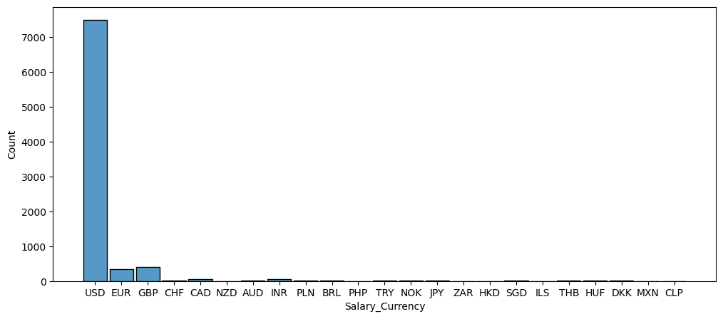

```python
fig, ax = plt.subplots(figsize=(12, 5))
histplot(
    x = data['Salary_Currency'],
    shrink=0.9,
    ax=ax

)

display(data['Salary_Currency'].value_counts().to_dict())
plt.show()
```

```python
data = data.groupby('Salary_Currency').filter(lambda x: len(x) >= 10)
```

```python
uniques = dict()
for col in data.columns:
    uniques[col] = list(data[col].unique())
```

#### Reasons for Currency Distribution in the Dataset

1. **USD Dominance in the Dataset**:
   - The dominance of USD in the dataset may be due to the fact that the United States is a major hub for data science and technology companies. Salaries in the tech industry are often benchmarked in USD, leading to a higher prevalence of this currency in the dataset.
2. **Global Standard**:
   - USD is often used as a global currency for benchmarking salaries, especially in multinational companies. This could explain why USD is the most prevalent currency in the dataset, followed by GBP and then EUR.
3. **Exchange Rate Stability**:
   - The stability of exchange rates could also play a role in the prevalence of certain currencies. USD is known for its stability in the global market, making it a preferred choice for salary benchmarking and reporting.

### 2.2 Convert Currencies

```python
# from forex_python.converter import CurrencyRates

# converter = CurrencyRates()

# exchange = dict()
# for currency in uniques['Salary_Currency']:
#     exchange[currency] = converter.get_rate(currency, 'USD')
# exchange
```

```python
exchange = {
    'USD': 1.0,
    'EUR': 1.0768,
    'GBP': 1.2578704514923194,
    'CAD': 0.7416999586719933,
    'AUD': 0.6519343706484229,
    'INR': 0.012047235725513668
}
```

```python
def convert_to_usd(row):
    currency = row['Salary_Currency']
    return row['Salary'] * exchange[currency]

data['Salary_USD'] = data.apply(convert_to_usd, axis=1)
```

## 3. Examine Jobs

### 3.1 fix job titles

```python
data['Job_Title'].replace('Business Intelligence', 'BI', inplace=True, regex=True)
data['Job_Title'].replace('Machine Learning', 'ML', inplace=True, regex=True)
# data['Job_Title'].replace('Data Science', 'Data Scientist', inplace=True, regex=True)
data['Job_Title'].replace('ML Ops', 'MLOps', inplace=True, regex=True)
data['Job_Title'].replace('Modeler', 'Modeller', inplace=True, regex=True)
```

### 3.2 Create Job_Type

```python
job_types = [
    'Engineer',
    'Developer',
    'Analyst',
    'Manager',
    'Consultant',
    'Architect',
    'Specialist',
    'Head',
    'Programmer',
    'Associate',
    'Lead',
    'Owner',
    'Scientist',
    'Modeller',
    'Researcher',
    'Director',
    'Technician',
    'Strategist',
    'Practitioner',
    # 'Data Science',
    # 'BI'

]
```

```python
data['Job_Type'] = data['Job_Title'].str.extract(f"({'|'.join(job_types)})")
job_types_mean_salary = data.groupby('Job_Type')['Salary_USD'].mean().sort_values()
job_types_mean_salary
```

```
Job_Type
Associate        60455.750000
Programmer       61973.360397
Owner            81904.347643
Technician       82777.500000
Specialist       96700.121371
Consultant      101766.912807
Strategist      105505.789474
Analyst         106762.943213
Developer       107786.986798
Modeller        131191.912409
Practitioner    136240.000000
Manager         143186.387817
Lead            148864.225970
Researcher      150606.899730
Scientist       158118.691612
Engineer        159696.323099
Architect       170294.716083
Head            209256.946831
Director        212136.214617
Name: Salary_USD, dtype: float64
```

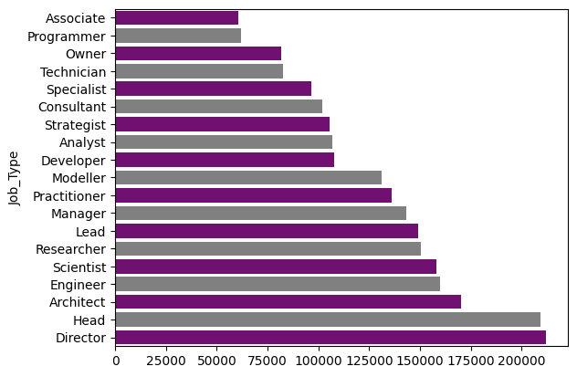

```python
barplot(
    x = job_types_mean_salary.values,
    y = job_types_mean_salary.index,
    palette = ['purple', 'gray']
)
plt.show()
```

we can see (as it was expected) some jobs like associate, programmer and consultant have much less salary compare to head, artchitect and director.

```python
data[data['Job_Type'].isna()]['Job_Title'].value_counts()
```

```
Data Science    140
BI               29
Name: Job_Title, dtype: int64
```

## 4. Label Encoding

Because some categorical features have order, we label them manually.

```python
numericData = data.copy(deep = True)
numericData['Experience_Level'] = data['Experience_Level'].apply(
    lambda x: ['Entry-Level', 'Mid-Level', 'Senior-Level', 'Executive-Level'].index(x))
numericData['Company_Size'] = data['Company_Size'].apply(
    lambda x: ['S', 'Medium', 'Large'].index(x))
numericData, labels = Utils.encode_categories(numericData)
numericData
```

|  | Work_Year | Experience_Level | Salary | Remote_Ratio | Company_Size | Salary_USD | Employment_Type | Job_Title | Salary_Currency | Job_Type |
| --- | --- | --- | --- | --- | --- | --- | --- | --- | --- | --- |
| 0 | 2024 | 2 | 90000 | 0 | 2 | 90000.000000 | 2 | 2 | 5 | 6 |
| 1 | 2024 | 2 | 180500 | 0 | 1 | 180500.000000 | 2 | 104 | 5 | 6 |
| 2 | 2024 | 2 | 96200 | 0 | 1 | 96200.000000 | 2 | 104 | 5 | 6 |
| 3 | 2024 | 2 | 235000 | 0 | 1 | 235000.000000 | 2 | 104 | 5 | 6 |
| 4 | 2024 | 2 | 175000 | 0 | 1 | 175000.000000 | 2 | 104 | 5 | 6 |
| ... | ... | ... | ... | ... | ... | ... | ... | ... | ... | ... |
| 13967 | 2020 | 2 | 412000 | 100 | 2 | 412000.000000 | 2 | 79 | 5 | 15 |
| 13968 | 2021 | 1 | 151000 | 100 | 2 | 151000.000000 | 2 | 124 | 5 | 15 |
| 13969 | 2020 | 0 | 105000 | 100 | 0 | 105000.000000 | 2 | 79 | 5 | 15 |
| 13970 | 2020 | 0 | 100000 | 100 | 2 | 100000.000000 | 0 | 31 | 5 | 0 |
| 13971 | 2021 | 2 | 7000000 | 50 | 2 | 84330.650079 | 2 | 76 | 4 | 9 |

8360 rows × 10 columns

## 5. Quick General informations

we can show `median`, `mode` and `mean` for numeric features and `mode` for categorical ones.

```python
Utils.describe(data)
```

```
feature: Work_Year
mode: 2023
mean: 2023.0964114832536
median: 2023.0
------------------------------------
feature: Experience_Level
mode: Senior-Level
------------------------------------
feature: Employment_Type
mode: Full-Time
------------------------------------
feature: Job_Title
mode: Data Engineer
------------------------------------
feature: Salary
mode: 100000
mean: 163002.71291866028
median: 140000.0
------------------------------------
feature: Salary_Currency
mode: USD
------------------------------------
feature: Remote_Ratio
mode: 0
mean: 37.02153110047847
median: 0.0
------------------------------------
feature: Company_Size
mode: Medium
------------------------------------
feature: Salary_USD
mode: 150000.0
mean: 147311.23209315032
median: 139000.0
------------------------------------
feature: Job_Type
mode: Engineer
------------------------------------
```

## 6. Histograms

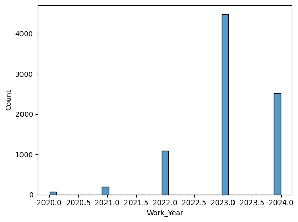

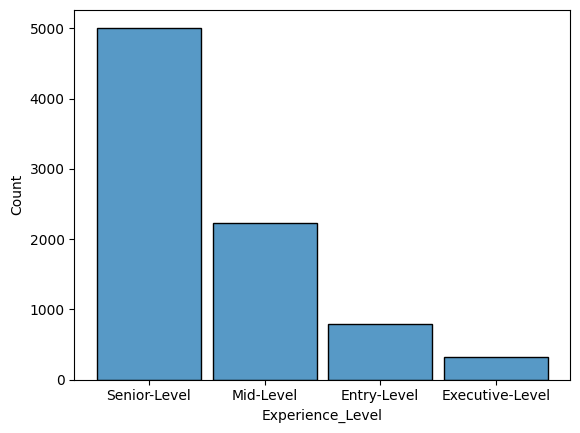

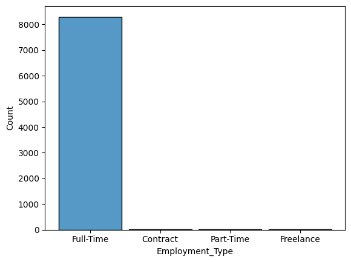

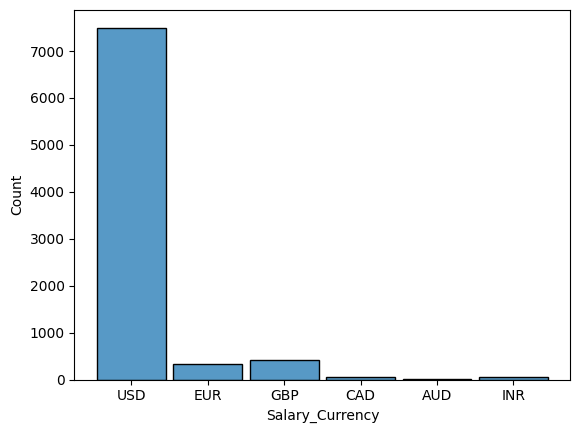

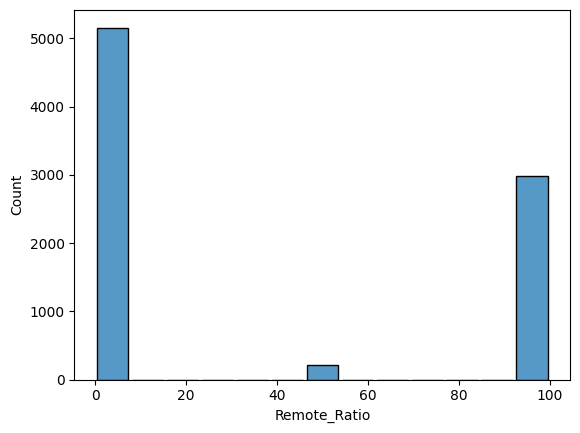

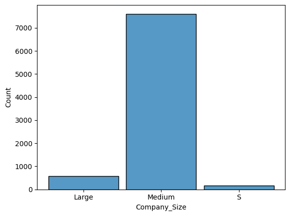

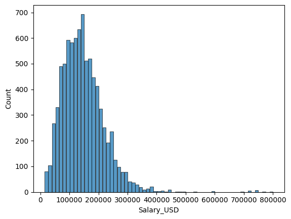

```python
features = [x for x in data.columns if x not in ['Salary', 'Job_Title', 'Job_Type']]
for col in features:
    histplot(
        x = data[col],
        bins='scott',
        shrink=0.9,
    )
    plt.show()
```

#### 6.1 Analysis of Histograms

In this part we can see the different aspects of our dataset.

## 7. Correlation of Features

There is no considerable information in the correlations.

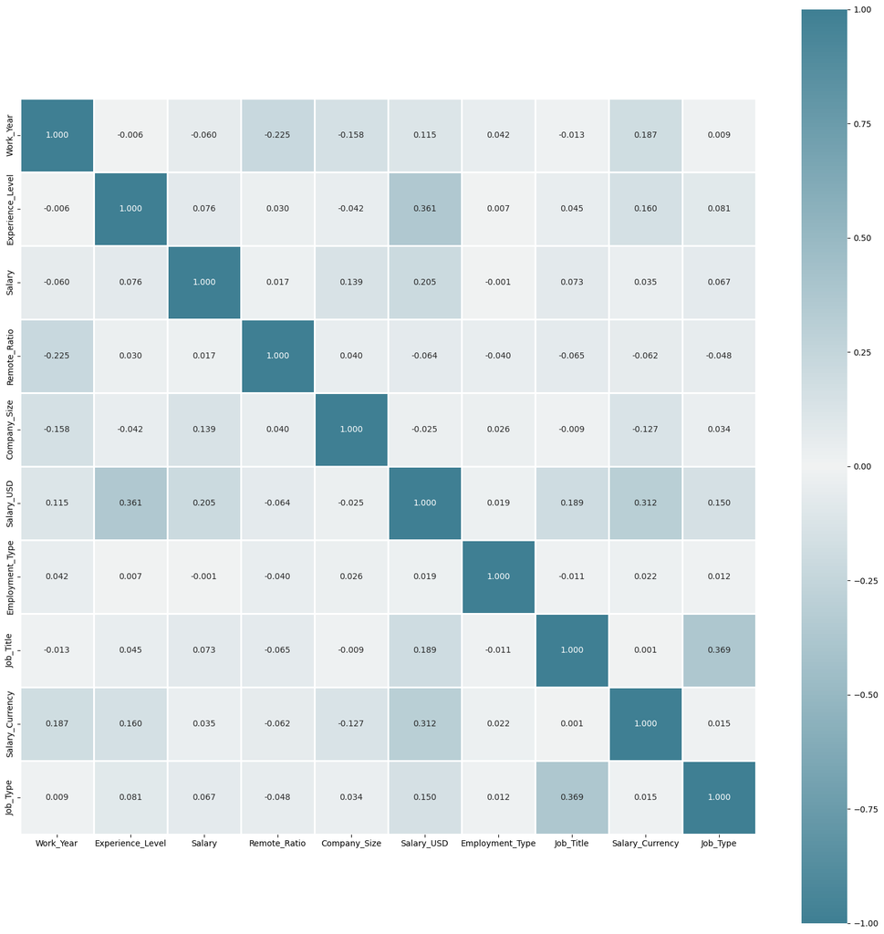

```python
Utils.corr_heatmap(numericData)
```

## 8. Relation of Features with Salary

```python
numericData.corr()['Salary_USD']
```

```
Work_Year           0.114973
Experience_Level    0.361041
Salary              0.205187
Remote_Ratio       -0.063816
Company_Size       -0.025100
Salary_USD          1.000000
Employment_Type     0.018626
Job_Title           0.189305
Salary_Currency     0.312180
Job_Type            0.149535
Name: Salary_USD, dtype: float64
```

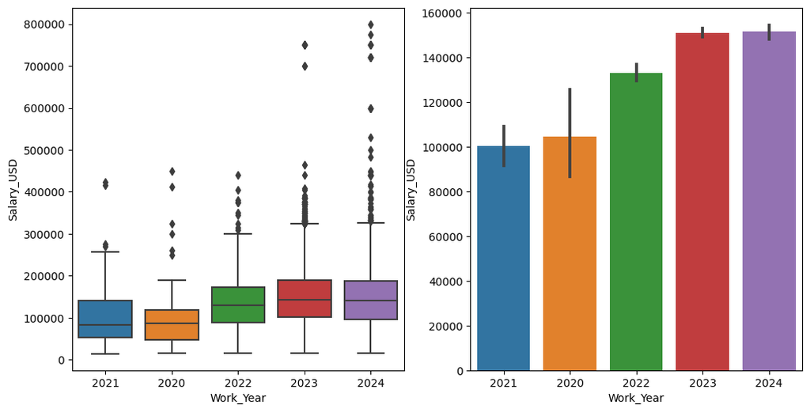

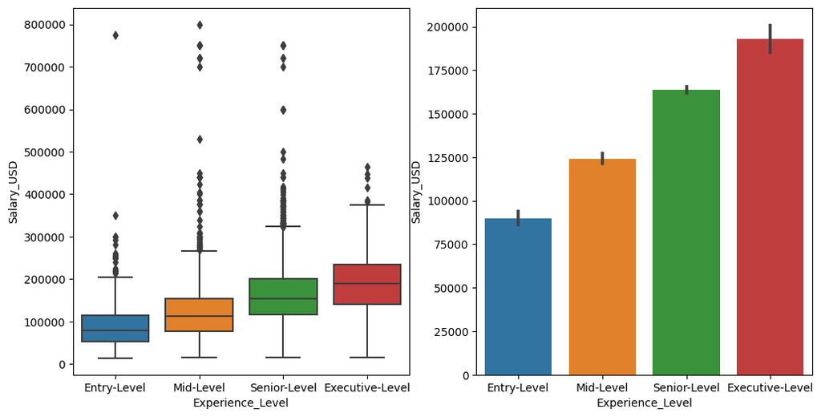

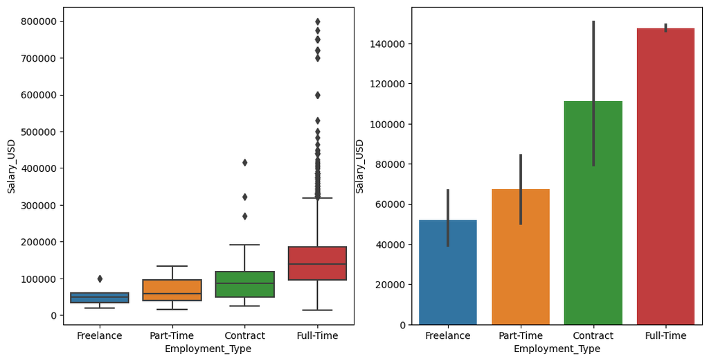

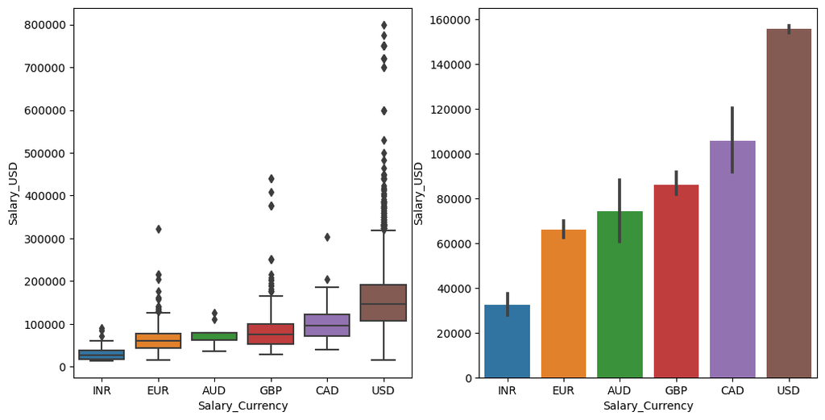

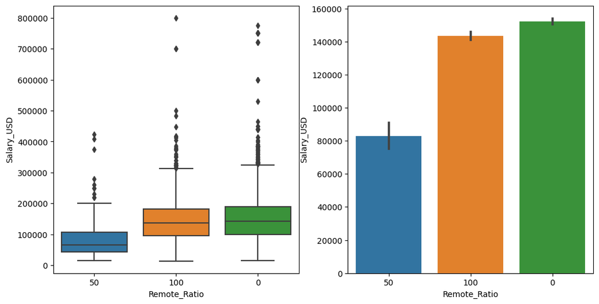

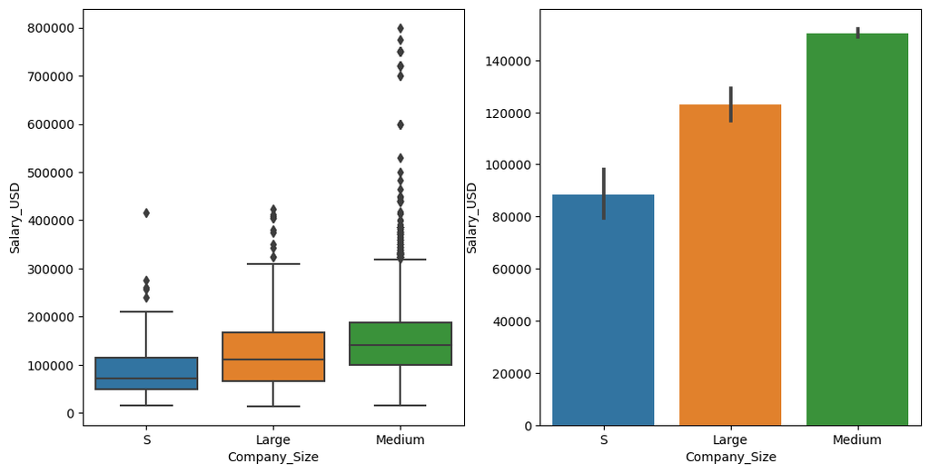

```python
features = [x for x in data.columns if x not in ['Salary', 'Job_Title', 'Salary_USD', 'Job_Type']]

for feature in features:
    Utils.plot_categorical_numeric_relation(
        data = data,
        numeric_col = 'Salary_USD',
        category_col = feature,
        plots = ['barplot', 'boxplot']
    )
```

#### 8.1.1 Analysis of Salary from 2021 to 2024

- We can see that throughout 2021 to 2024, the average salary have rised. This can be due to inflation and increase of living cost and also the trend in AI related jobs.
- Also the number of outliers in 2023 and 2024 is much more than the others, meaning that the need to employ exprets, which gain much more in salary, in AI related jobs have risen.

#### 8.1.2 Analysis of Salary Based on Experience

- As it was expected, the more experienced eployees have more salary than the others.
- One of the intresting points is that the number and distribution of outliers in Exectuive-Level is less than the others. Even some Entry-Levels gain more than the Execeutive-Levels.
- It can be implicated that the salaries in high level jobs is more stable, despite of being higher than the others.

#### 8.1.3 Analysis of Salary Based on Employment Type

- It can be observed that the Full-Time jobs have more salaries than the others. It was expected as the companies's need to full timers is more and they are willing to pay them more.
- As of outliers, we can see that there are some Contract employees that gain more than the full timers. They may be some high level specialists in their fields which accept some projects and receive much money for that.
- Also full timers have many outliers, indicating the importance of these type of employment and companies tend for paying them more.

#### 8.1.4 Analysis of Salary Based on the Currency

- The salaries in USA is higher than the other countries. It can be due to many large companies that are based in USA, high competition of employment of high level specialists and also the much bigger economy of the USA.
- The payments in more advanced countries like USA, Canada and England are higher than the others, indicating the investments that are being made on the AI in these countries.
- Also the low salaries in less advanced countries like India, show that these jobs are not a big trend in these countries or showing their smaller economy.

#### 8.1.5 Analysis of Salary Based on the Remote Ratio

- Companies with small or large ratios of remote jobs tend to offer higher salaries compared to those with a middle ratio. This is likely due to heightened competition for remote talent, specialization in niche areas, and market positioning as remote-friendly employers.
- Additionally, cost of living considerations and strategies to retain top talent and ensure productivity may contribute to the higher salaries.
- Overall, companies with extreme ratios of remote jobs—either very small or very large—may offer more attractive compensation packages to compete for talent in specialized or remote-friendly markets.

#### 8.1.6 Analysis of Salary Based on the Company Size

- In the AI industry, medium-sized companies stand out for offering competitive salaries, potentially reflecting their ability to invest in talent while maintaining operational efficiency. This suggests a strategic balance between attracting skilled professionals and managing costs.
- Additionally, the wider distribution of salaries within medium-sized companies implies a diverse workforce with varying skill levels and responsibilities, fostering a dynamic and inclusive work environment.
- However, the lower average salaries offered by small-sized companies may indicate limitations in resources or market competitiveness, while the relatively standardized salaries in large-sized companies may suggest a more structured compensation approach.
- Overall, medium-sized companies emerge as key players in the AI industry, offering both competitive salaries and opportunities for career growth and diversity.

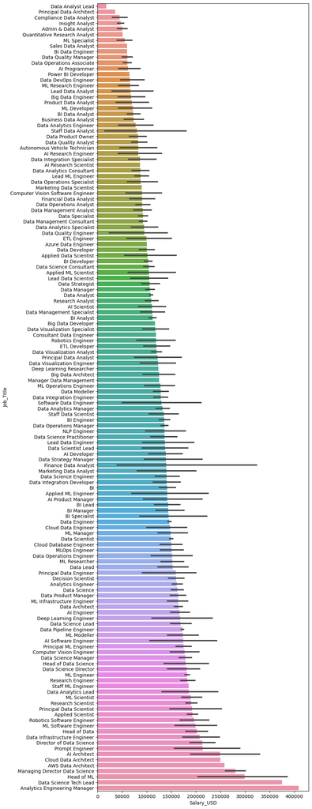

```python
figure, ax = plt.subplots(figsize = (8, 30))
barplot(
    data = data,
    x = 'Salary_USD',
    y = 'Job_Title',
    estimator = 'mean',
    order = data.groupby('Job_Title')['Salary_USD'].mean().sort_values().index.to_list()
)
plt.show()
```

## 9. Relation of Features with Remote Ratio

### 9.1 Remote Ratio in Different Categories

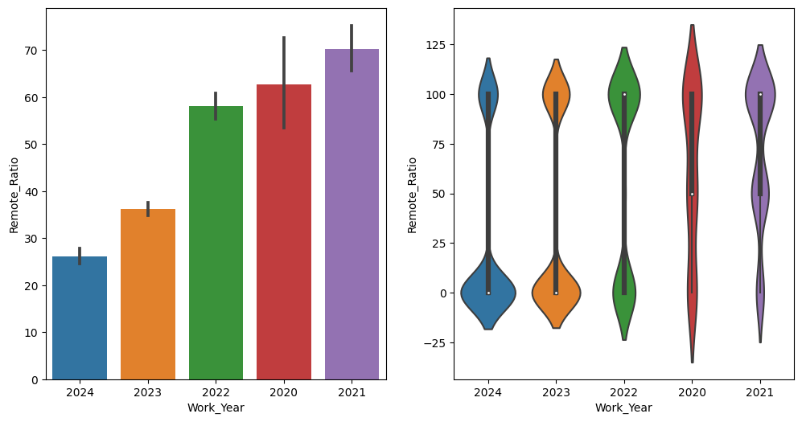

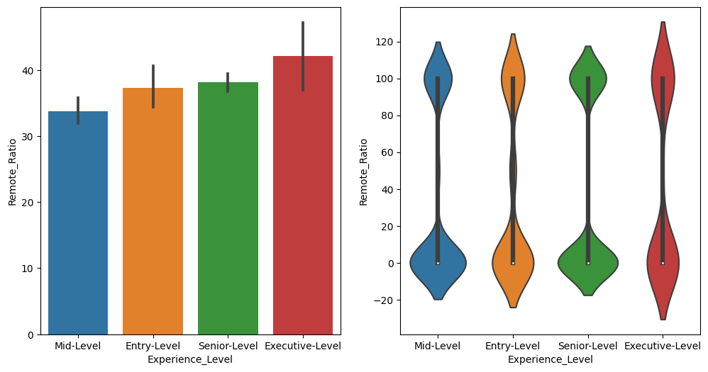

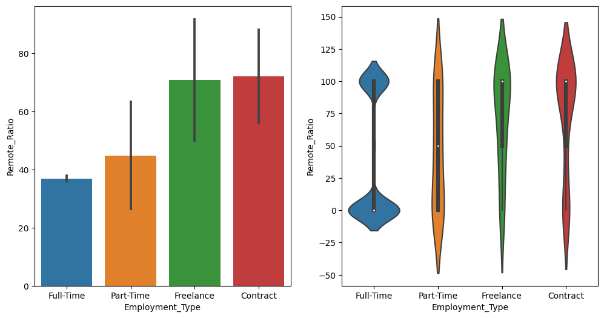

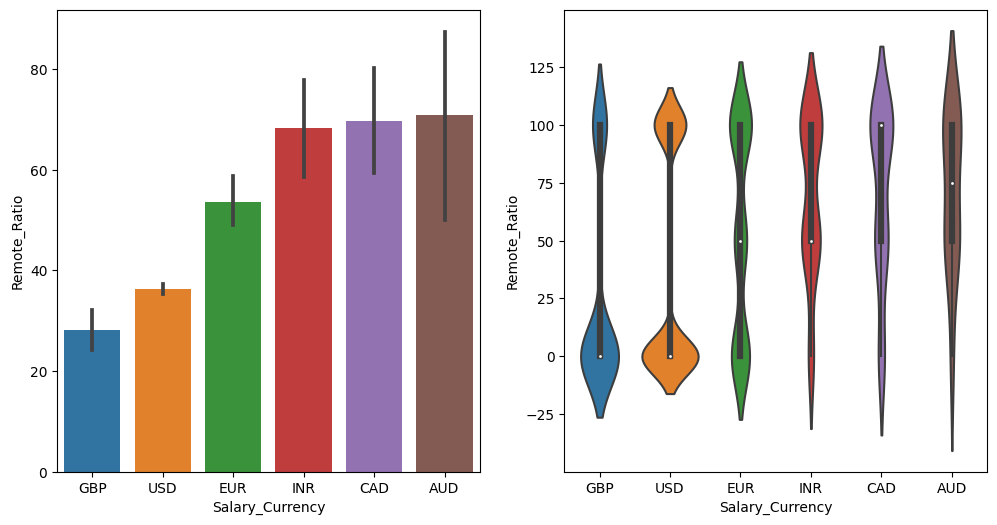

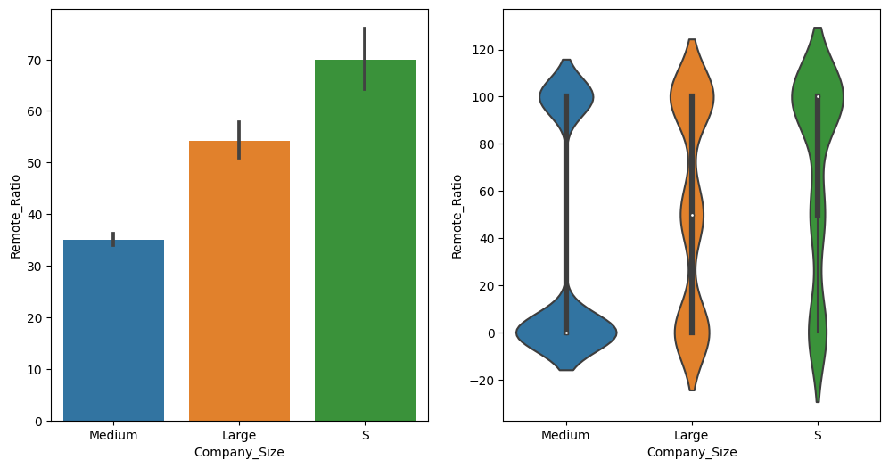

```python
features = [x for x in data.columns if x not in ['Salary', 'Job_Title', 'Salary_USD', 'Remote_Ratio', 'Job_Type']]
for feature in features:
    Utils.plot_categorical_numeric_relation(
        data = data,
        numeric_col = 'Remote_Ratio',
        category_col = feature,
        plots = ['violinplot', 'barplot']
    )
```

#### 9.1.1 Analysis of Remote Work Ratio from 2021 to 2024

1. **Remote Work Ratio in 2021**:
   - In 2021, the dataset shows that the remote work ratio was the highest compared to other years. This could be attributed to the global shift towards remote work due to the COVID-19 pandemic. Many companies adopted remote work policies to ensure employee safety and business continuity, leading to a significant increase in remote work opportunities for data scientists.
2. **Remote Work Ratio Decline by 2024**:
   - The dataset indicates that by 2024, the remote work ratio has decreased and is at its lowest compared to previous years. This decline could be a result of various factors such as the easing of pandemic restrictions, companies transitioning back to traditional office setups, or changes in remote work policies and preferences among employers and employees.
3. **Reasons for Decline**:
   - The decrease in remote work ratio by 2024 may be influenced by factors such as the resurgence of in-person collaboration, the need for team synergy, the desire for face-to-face interactions, or organizational strategies to enhance productivity and innovation through on-site work environments.

#### 9.1.3 Analysis of Remote Work Ratio Across Employment Types

1. **Contract Employees**:
   - The dataset indicates that contract employees have the highest remote work ratio among the employment types considered. Contract roles often involve project-based work with defined deliverables, allowing for greater flexibility in work arrangements, including remote work options. Contract employees may work independently on specific projects, which can be done remotely without the need for constant on-site presence.
2. **Freelance Workers**:
   - Freelance workers have a lower remote work ratio compared to contract employees in the dataset. While freelancers also enjoy flexibility in their work schedules and locations, the nature of freelance work may vary in terms of client interactions, project timelines, and on-site requirements, leading to a slightly lower remote work ratio than contract roles.
3. **Part-Time Employees**:
   - Part-time employees exhibit a lower remote work ratio compared to freelance workers in the dataset. Part-time positions often involve set hours or shifts within a specific timeframe, which may require on-site presence for coordination, training, or task completion. This can limit the remote work opportunities for part-time employees relative to freelancers and contract workers.
4. **Full-Time Employees**:
   - Full-time employees have the lowest remote work ratio among the employment types analyzed. Full-time roles typically involve regular hours, team collaboration, and ongoing responsibilities that may necessitate on-site presence for meetings, supervision, and project coordination. While some full-time positions offer remote work options, they may be less common compared to contract, freelance, and part-time roles.
5. **Factors Influencing Remote Work Ratios**:
   - The remote work ratios across different employment types are influenced by factors such as job structure, project requirements, client expectations, company policies, and individual preferences. Understanding these dynamics can help organizations tailor remote work opportunities to meet the diverse needs of employees across various employment arrangements.

#### 9.1.4 Analysis of Remote Work Ratio Across Currency Types

Analyzing the remote work ratios across different currency types (AUD, CAD, INR, EUR, USD, GBP) reveals a specific order of remote work preferences based on the dataset provided. Understanding the remote work preferences based on currency types provides valuable insights into regional work dynamics, cultural influences, and organizational trends shaping remote work practices within the data science industry. Tailoring remote work strategies to align with currency-specific preferences can optimize workforce engagement, performance, and satisfaction in a diverse and dynamic work environment.

#### 9.1.5 Analysis of Remote Work Ratios Across Company Sizes

1. **Small Companies**:
   - The dataset indicates that small companies exhibit the highest remote work ratio among the company sizes considered. Small businesses often prioritize flexibility, agility, and remote work opportunities to attract and retain talent, optimize resources, and adapt to changing market dynamics. The remote work ratio in small companies may be influenced by factors such as organizational culture, technology adoption, and employee preferences for remote work arrangements.
2. **Large Companies**:
   - Following small companies, large companies show a moderate remote work ratio in the dataset. While large corporations have the resources and infrastructure to support remote work initiatives, the remote work ratio for large companies indicates a slightly lower preference for remote work compared to small businesses. Large companies may have more complex structures, diverse teams, and operational considerations that impact remote work implementation and adoption.
3. **Medium-sized Companies**:
   - The dataset reveals that medium-sized companies have the lowest remote work ratio among the company sizes analyzed. Medium-sized businesses often balance the operational challenges of remote work with the need for on-site collaboration, team coordination, and organizational alignment. The remote work ratio for medium-sized companies suggests a relatively lower emphasis on remote work compared to small and large companies.
4. **Factors Influencing Remote Work Ratios**:
   - The remote work preferences across company sizes are influenced by factors such as company culture, organizational structure, leadership practices, technological capabilities, and industry norms. Small companies may have remote work as a advantage to get innovation and talent retention, while large companies navigate the complexities of scale, compliance, and organizational dynamics in implementing remote work practices.

### 9.2 Remote Ratio in Different Jobs

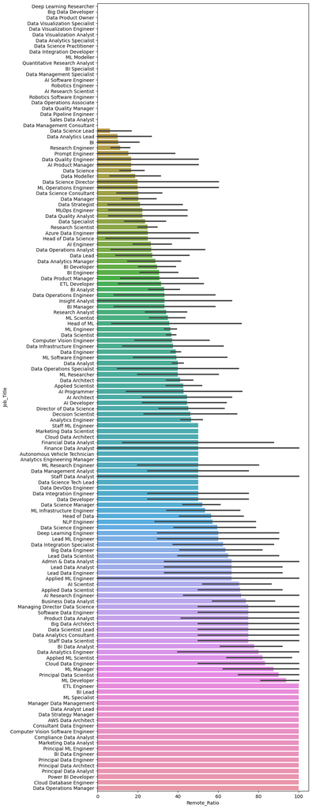

```python
figure, ax = plt.subplots(figsize = (8, 30))
barplot(
    data = data,
    x = 'Remote_Ratio',
    y = 'Job_Title',
    estimator = 'mean',
    order = data.groupby('Job_Title')['Remote_Ratio'].mean().sort_values().index.to_list()
)
plt.show()
```

This plot shows the remote ratio of each job title.

We can observe that some jobs are fully remote. This can be in a result of low number of data from that jobs so that all the data we have show they are remote only. Also vice-versa for the jobs that have no number of the remote employees.

## 10. Histogram by each group

```python
hist_x_by_y = {
    'Company_Size': ['Job_Type', 'Remote_Ratio', 'Employment_Type', 'Experience_Level'],
    'Experience_Level': ['Employment_Type', 'Remote_Ratio']
}
```

```
histogram of Job_Type by Company_Size
```

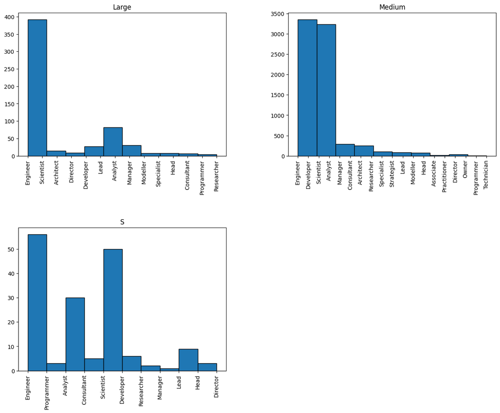

```
histogram of Remote_Ratio by Company_Size
```

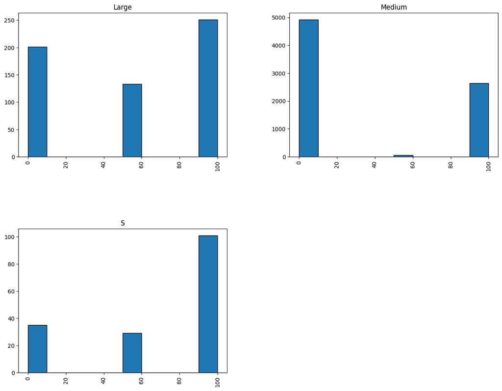

```
histogram of Employment_Type by Company_Size
```

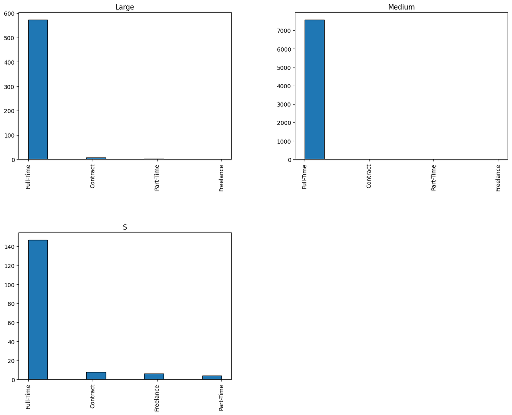

```
histogram of Experience_Level by Company_Size
```

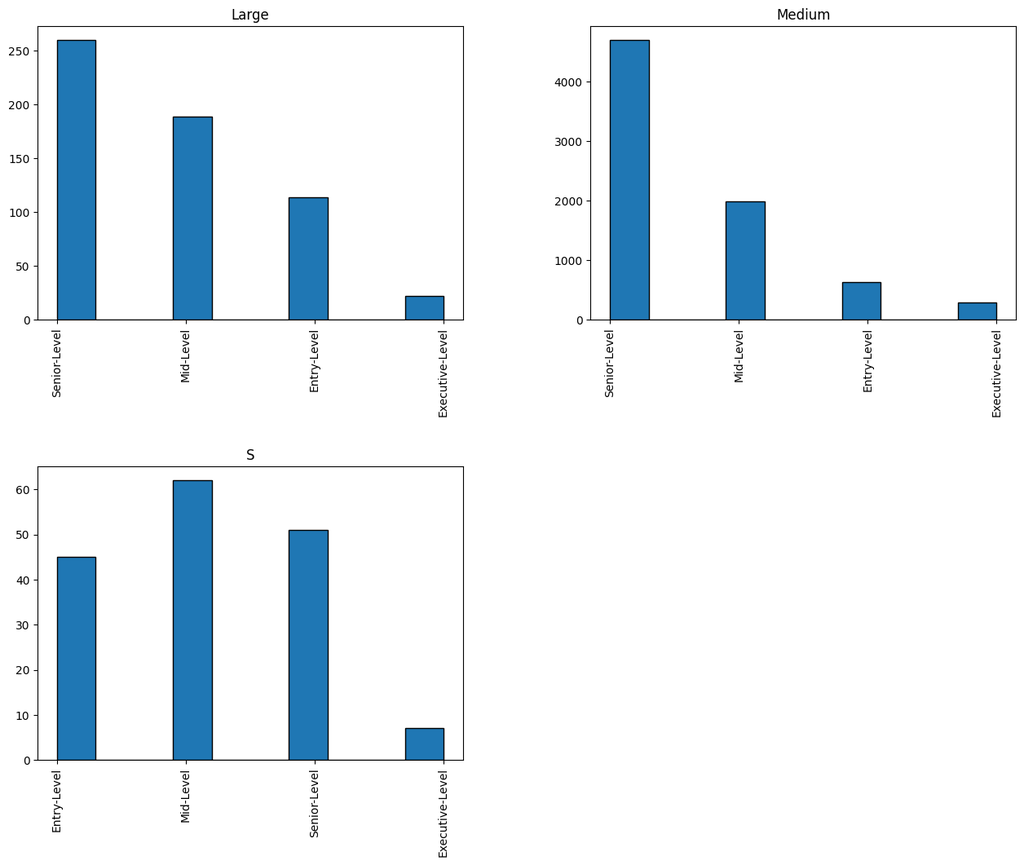

```
histogram of Employment_Type by Experience_Level
```

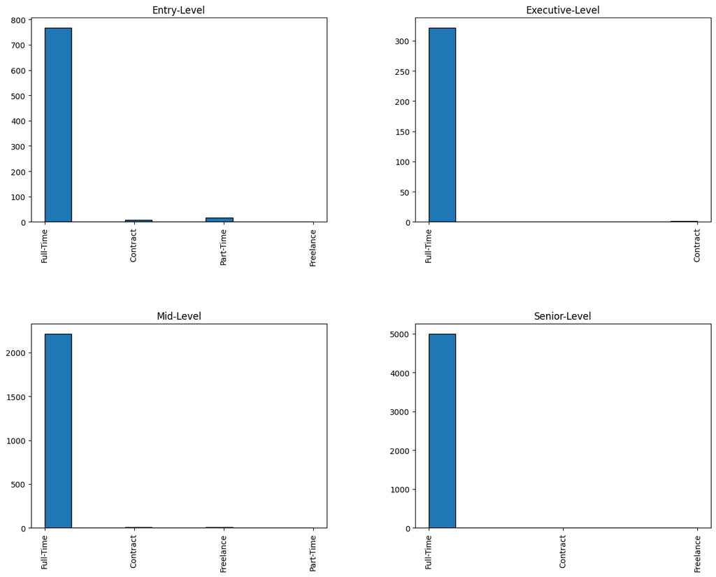

```
histogram of Remote_Ratio by Experience_Level
```

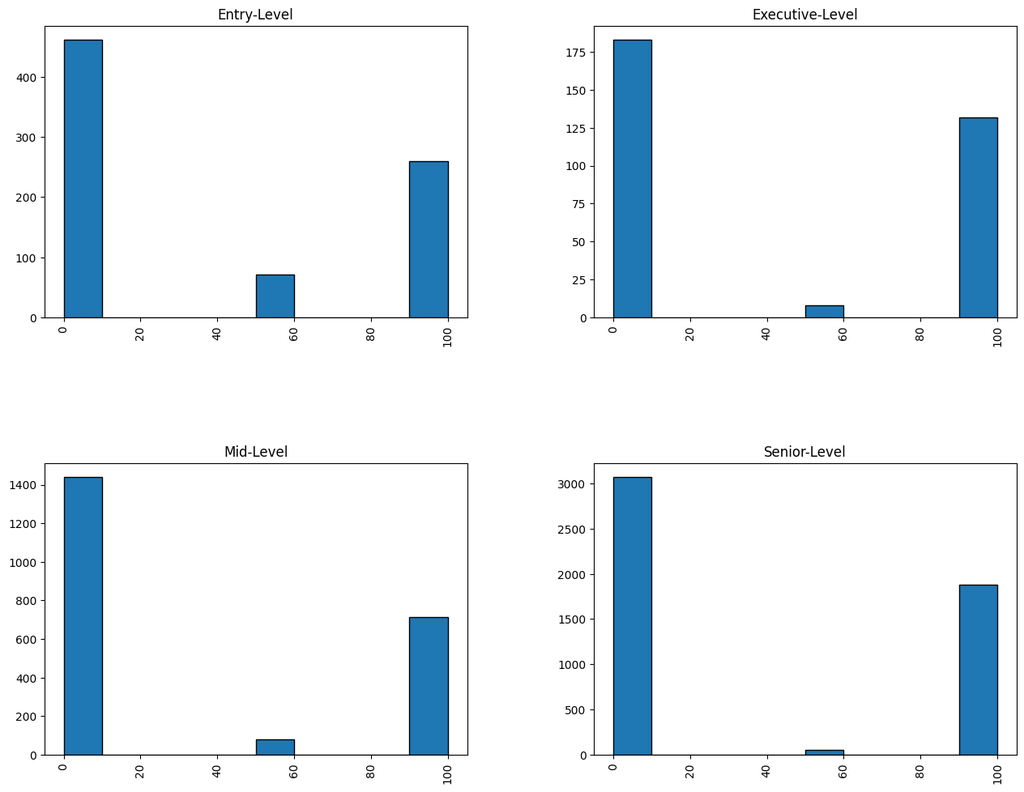

```python
for y in hist_x_by_y:
    for x in hist_x_by_y[y]:
        print(f'histogram of {x} by {y}')
        data.hist(x, by = y, figsize=(15, 12), ec = 'black')
        plt.show()
```

#### 10.2 By Experience Level

- Employment Type:
  - Entry level people are employed in variant types, while others are employed in full time mostly.
- Remote Ratio:
  - Theres is no significant difference in different exeprience levels.

## 11. Histogram Through Years

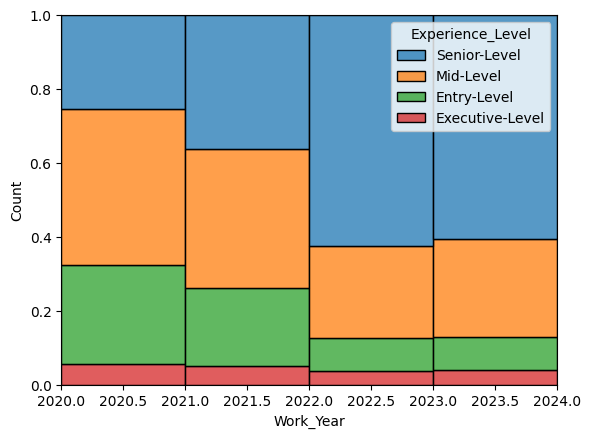

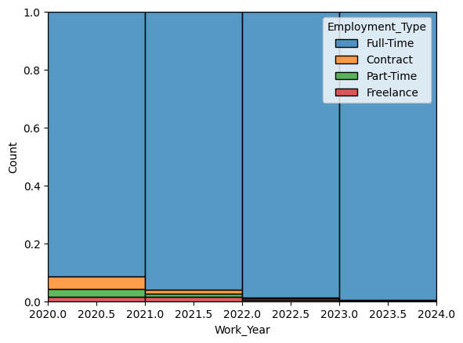

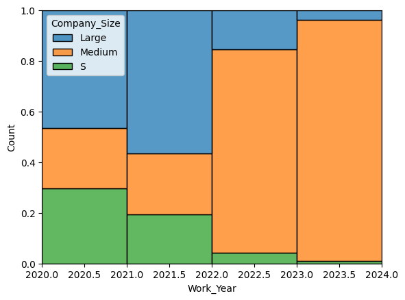

```python
features = ['Experience_Level', 'Employment_Type', 'Company_Size']
for feature in features:
    histplot(
        data = data,
        x = 'Work_Year',
        hue = feature,
        multiple='fill',
        bins = range(2020, 2025)
    )
    plt.show()
```

#### Analysis of Employee Distribution Across Job Levels in 2020-2024

- The surge in senior-level employees in 2022 indicates a strategic focus on experienced leadership, likely driven by the need for seasoned professionals to guide strategic initiatives and navigate challenges in the AI sector.
- Reductions in entry-level and mid-level employees suggest organizational restructuring or streamlined processes, possibly to optimize operations and adapt to changing skill requirements.
- Executive-level stability amidst workforce changes reflects a deliberate effort to maintain leadership cohesion and strategic direction. Overall, these shifts underscore the importance of strategic talent management in fostering organizational agility and resilience in the dynamic AI landscape.

#### Analysis of Employment Types in Jobs in 2020-2024

- In 2020, full-time employment dominated the landscape, comprising over 90% of all employment types in the AI industry. However, over the following years, the dominance of full-time positions continued to grow, potentially reaching over 98% by 2024. Concurrently, the numbers of other employment types—contract, part-time, and freelance—decreased significantly, indicating a shift towards a more traditional and stable employment model within the industry.
- This trend suggests that despite fluctuations and changes in the job market, full-time employment remains the preferred choice for both employers and employees in the AI sector. It reflects the industry's inclination towards long-term commitments, stability, and the need for dedicated professionals to drive innovation and growth. Additionally, the decline in alternative employment arrangements indicates a possible preference for the security and benefits associated with full-time positions among workers in the AI industry.

#### Analysis of Company Sizes in Market int 2020-2024

This progressive shift towards dominance by medium-sized companies suggests a dynamic and evolving landscape, with opportunities for innovation, growth, and strategic partnerships within this segment.